# Analysis of metaphoricity & creativity

Anonymous

19/04/2021

## Prelims

Load packages:

```r
library(tidyverse)
library(brms)
library(ggridges)
library(patchwork)
```

Load experiment data:

```r
E1 <- read_csv('../data/E1_data.csv')
E2 <- read_csv('../data/E2_data.csv')
```

Load stimulus characteristics:

```r
stims <- read_csv('../data/stimuli.csv')
```

For reproducibility, report R version, and brms package version:

```r
R.Version()$version.string
```

```
## [1] "R version 3.6.1 (2019-07-05)"
```

```r
packageVersion('brms')
```

```
## [1] '2.10.0'
```

```r
packageVersion('tidyverse')
```

```
## [1] '1.3.0'
```

```r
packageVersion('ggridges')
```

```
## [1] '0.5.1'
```

```r
packageVersion('patchwork')
```

```
## [1] '1.1.1'
```

brms settings for faster computing:

```r
options(mc.cores=parallel::detectCores())
```

## Data cleaning

Rename ID column to something shorter:

```r
E1 <- rename(E1, ID = ResponseId)
E2 <- rename(E2, ID = ResponseId)
```

This data is complete (there is no incomplete data, as otherwise it would not be moved to completed responses from Qualtrics).

Check whether exclusions need to be performed because of the catch trial. The answer was 5:

```r
all(E1$CatchTrial == 5)
```

```
## [1] TRUE
```

```r
all(E2$CatchTrial == 5)
```

```
## [1] TRUE
```

Exclusions because of native speakers?

```r
E1 %>% count(NativeSpeaker)
```

```
## # A tibble: 2 x 2
##   NativeSpeaker                                                                n
##   <chr>                                                                    <int>
## 1 Yes, I grew up speaking English at home, but I also spoke other languag~     2
## 2 Yes, I grew up speaking only English at home                                48
```

```r
E2 %>% count(NativeSpeaker)
```

```
## # A tibble: 3 x 2
##   NativeSpeaker                                                                n
##   <chr>                                                                    <int>
## 1 No, I did not grow up speaking English at home                               2
## 2 Yes, I grew up speaking English at home, but I also spoke other languag~     2
## 3 Yes, I grew up speaking only English at home                                46
```

Exclude:

```r
E2 <- filter(E2, NativeSpeaker != "No, I did not grow up speaking English at home")
```

Make into long format:

```r
E1
```

```
## # A tibble: 50 x 63
##    StartDate EndDate Progress `Duration (in s~ Finished RecordedDate ID
##    <chr>     <chr>      <dbl>            <dbl> <lgl>    <chr>        <chr>
##  1 19/04/20~ 19/04/~      100              318 TRUE     19/04/2021 ~ R_D7~
##  2 19/04/20~ 19/04/~      100              371 TRUE     19/04/2021 ~ R_1z~
##  3 19/04/20~ 19/04/~      100              299 TRUE     19/04/2021 ~ R_3P~
##  4 19/04/20~ 19/04/~      100             1140 TRUE     19/04/2021 ~ R_1O~
##  5 19/04/20~ 19/04/~      100              788 TRUE     19/04/2021 ~ R_1C~
##  6 19/04/20~ 19/04/~      100              755 TRUE     19/04/2021 ~ R_3K~
##  7 19/04/20~ 19/04/~      100              295 TRUE     19/04/2021 ~ R_3K~
##  8 19/04/20~ 19/04/~      100              316 TRUE     19/04/2021 ~ R_Bz~
##  9 19/04/20~ 19/04/~      100              205 TRUE     19/04/2021 ~ R_22~
## 10 19/04/20~ 19/04/~      100              231 TRUE     19/04/2021 ~ R_1O~
## # ... with 40 more rows, and 56 more variables: CatchTrial <dbl>, Item_1 <chr>,
## #   Item_2 <chr>, Item_3 <chr>, Item_4 <chr>, Item_5 <chr>, Item_6 <chr>,
## #   Item_7 <chr>, Item_8 <chr>, Item_9 <chr>, Item_10 <chr>, Item_11 <chr>,
## #   Item_12 <chr>, Item_13 <chr>, Item_14 <chr>, Item_15 <chr>, Item_16 <chr>,
## #   Item_17 <chr>, Item_18 <chr>, Item_19 <chr>, Item_20 <chr>, Item_21 <chr>,
## #   Item_22 <chr>, Item_23 <chr>, Item_24 <chr>, Item_25 <chr>, Item_26 <chr>,
## #   Item_27 <chr>, Item_28 <chr>, Item_29 <chr>, Item_30 <chr>, Item_31 <chr>,
## #   Item_32 <chr>, Item_33 <chr>, Item_34 <chr>, Item_35 <chr>, Item_36 <chr>,
## #   Item_37 <chr>, Item_38 <chr>, Item_39 <chr>, Item_40 <chr>, Item_41 <chr>,
## #   Item_42 <chr>, Item_43 <chr>, Item_44 <chr>, Item_45 <chr>, Item_46 <chr>,
## #   Item_47 <chr>, Item_48 <chr>, Item_49 <chr>, Item_50 <chr>,
## #   Debriefing <chr>, NativeSpeaker <chr>, OtherLanguages <chr>, Age <dbl>,
## #   Gender <chr>
```

Check number of participants:

```r
nrow(E1)
```

```
## [1] 50
```

```r
nrow(E2)
```

```
## [1] 48
```

Check number of male/female participants:

```r
E1 %>% count(Gender)
```

```
## # A tibble: 2 x 2
##   Gender     n
##   <chr>  <int>
## 1 Female    23
## 2 Male      27
```

```r
E2 %>% count(Gender)
```

```
## # A tibble: 2 x 2
##   Gender     n
##   <chr>  <int>
## 1 Female    17
## 2 Male      31
```

Check age range and average age:

```r
mean(E1$Age)
```

```
## [1] 39.48
```

```r
range(E1$Age)
```

```
## [1] 19 67
```

```r
mean(E2$Age)
```

```
## [1] 36.16667
```

```r
range(E2$Age)
```

```
## [1] 22 53
```

## Convert to long format

Convert into long format:

```r
E1 <- pivot_longer(E1, Item_1:Item_50,
                   names_to = 'Item',
                   values_to = 'Response')
E2 <- pivot_longer(E2, Item_1:Item_50,
                   names_to = 'Item',
                   values_to = 'Response')
```

Make the response in an ordered variable:

```r
# Experiment 1:

E1 <- mutate(E1,
             Response = factor(Response,
                               levels = c('very literal', 'literal',
                                          'moderately literal', 'neutral',
                                          'moderately metaphoric', 'metaphoric',
                                          'very metaphoric')),
             ResponseNum = as.numeric(Response))

# Experiment 2:

E2 <- mutate(E2,
             Response = factor(Response,
                               levels = c('very uncreative', 'uncreative',
                                          'moderately uncreative', 'neutral',
                                          'moderately creative', 'creative',
                                          'very creative')),
             ResponseNum = as.numeric(Response))
```

Exclude straightliners. 40 times the same response is 80%, which was our pre-registered exclusion criterion. Is anybody above that?

```r
# Experiment 1:

E1 %>% count(ID, Response) %>%
  filter(n >= 40)
```

```
## # A tibble: 0 x 3
## # ... with 3 variables: ID <chr>, Response <fct>, n <int>
```

```r
# Experiment 2:

E2 %>% count(ID, Response) %>%
  filter(n >= 40)
```

```
## # A tibble: 0 x 3
## # ... with 3 variables: ID <chr>, Response <fct>, n <int>
```

Merge with stimulus characteristics:

```r
E1 <- left_join(E1, stims, by = c('Item' = 'ID'))
E2 <- left_join(E2, stims, by = c('Item' = 'ID'))
```

Descriptive statistics, average cosine per rating. 7 = very metaphoric; 1 = very literal

```r
E1_means <- E1 %>% group_by(Response) %>%
  summarize(M = mean(Cosine))
```

```r
E2_means <- E2 %>% group_by(Response) %>%
  summarize(M = mean(Cosine))
```

Make barplots of the averages:

```r
# Experiment 1:

E1_barplot <- E1_means %>%
  ggplot(aes(x = factor(Response),
             y = M)) +
  geom_bar(stat = 'identity') +
  ylab('Average cosine') +
  theme_minimal() +
  theme(axis.text.x = element_text(angle = 45, hjust = 1, vjust = 1),
        axis.title.x = element_blank())

# Experiment 2:

E2_barplot <- E2_means %>%
  ggplot(aes(x = factor(Response),
             y = M)) +
  geom_bar(stat = 'identity') +
  ylab('Average cosine') +
  theme_minimal() +
  theme(axis.text.x = element_text(angle = 45, hjust = 1, vjust = 1),
        axis.title.x = element_blank())
```

Save both externally:

```r
ggsave(plot = E1_barplot, filename = '../figures/E1_barplot.pdf',
       width = 8, height = 6)
ggsave(plot = E2_barplot, filename = '../figures/E2_barplot.pdf',
       width = 8, height = 6)
```

Show them in the R script, first, Experiment 1:

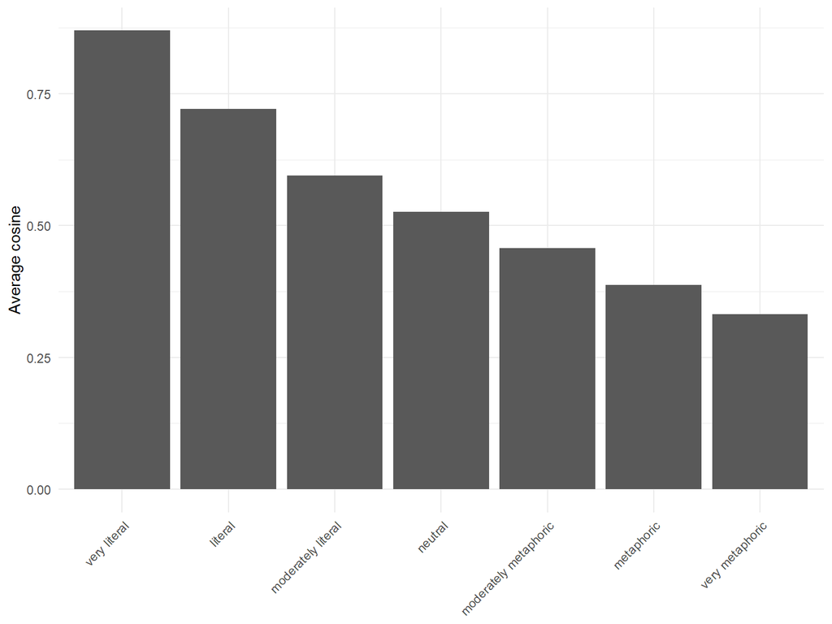

```r
E1_barplot
```

Then, Experiment 2:

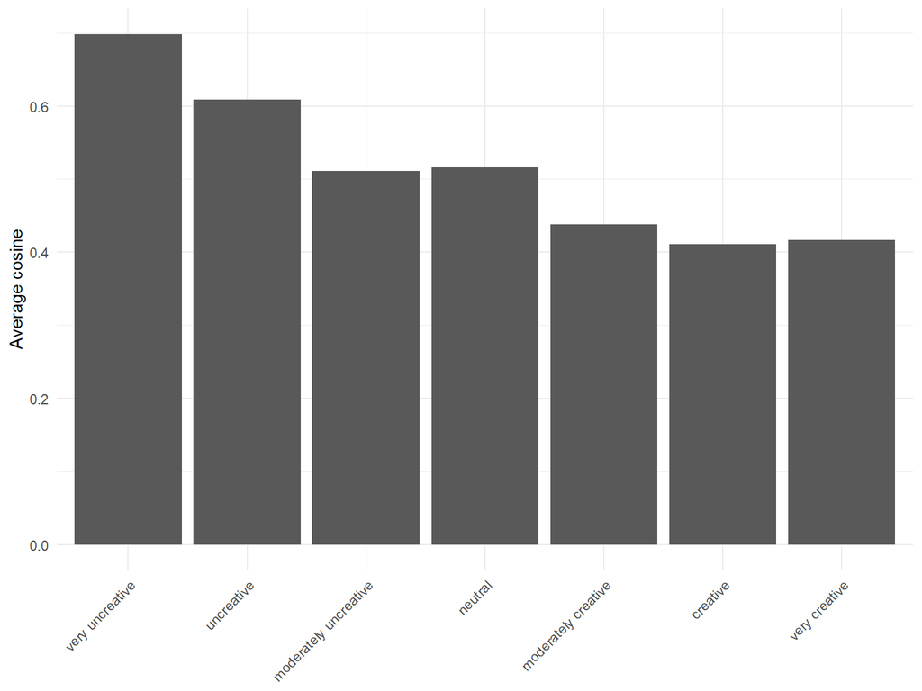

```r
E2_barplot
```

Round both means tables for reporting:

```r
E1_means <- mutate(E1_means, M = round(M, 2))
E2_means <- mutate(E2_means, M = round(M, 2))
```

Save externally:

```r
write_csv(E1_means, '../data/E1_means.csv')
write_csv(E2_means, '../data/E2_means.csv')
```

Make a joy plot of this:

```r
# Experiment 1:

E1_joy <- E1 %>% ggplot(aes(x = Cosine,
                       y = factor(Response))) +
  xlab('Cosine similarity') +
  geom_density_ridges() +
  # coord_cartesian(xlim = c(0, 1)) +
  theme_ridges() +
  theme(axis.title.y = element_blank(),
        axis.text.y = element_text(face = 'bold'),
        axis.title.x = element_text(face = 'bold', size = 16))

# Experiment 2:

E2_joy <- E2 %>% ggplot(aes(x = Cosine,
                       y = factor(Response))) +
  xlab('Cosine similarity') +
  geom_density_ridges() +
  # coord_cartesian(xlim = c(0, 1)) +
  theme_ridges() +
  theme(axis.title.y = element_blank(),
        axis.text.y = element_text(face = 'bold'),
        axis.title.x = element_text(face = 'bold', size = 16))
```

Show these in the script, Experiment 1:

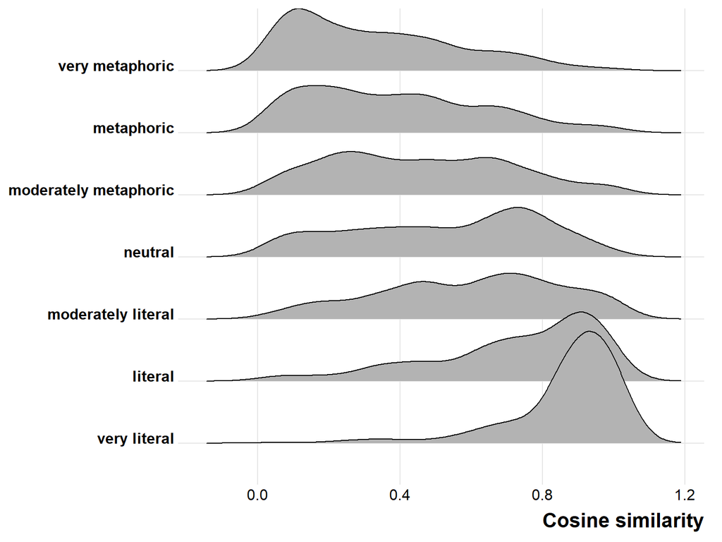

```r
E1_joy
```

Experiment 2:

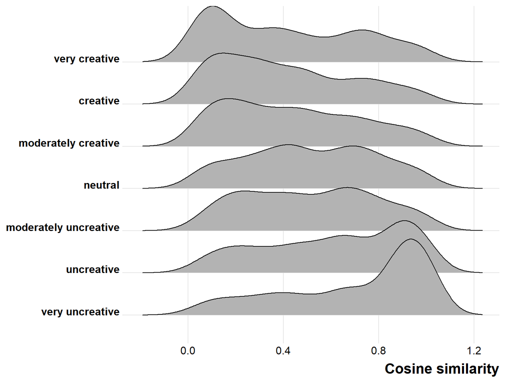

```r
E2_joy
```

Save both seperately:

```r
ggsave(plot = E1_joy, filename = '../figures/E1_joy_plot.pdf',
       width = 8, height = 6)
ggsave(plot = E2_joy, filename = '../figures/E2_joy_plot.pdf',
       width = 8, height = 6)
```

Put both together and save them in one:

```r
E1_joy <- E1_joy + ggtitle('(a) Experiment 1') +
  theme(plot.title = element_text(face = 'bold', size = 18,
                                  margin = margin(b = 20, t = 0,
                                                  r = 0, l = 0)))
E2_joy <- E2_joy + ggtitle('(b) Experiment 2') +
  theme(plot.title = element_text(face = 'bold', size = 18,
                                  margin = margin(b = 20, t = 0,
                                                  r = 0, l = 0)))

# Put both together:

both_joy <- E1_joy + E2_joy
```

Show in script:

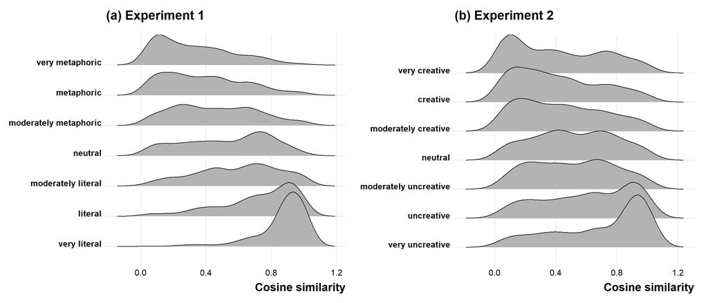

```r
both_joy
```

Save:

```r
ggsave(plot = both_joy, filename = '../figures/both_joy_plots.pdf',
       width = 12, height = 6)
```

## Corpus attestation descriptive stats

Check how corpus attestation influenced this:

```r
E1 %>% group_by(PairAttested) %>%
  summarize(M = mean(ResponseNum),
            SD = sd(ResponseNum))
```

```
## # A tibble: 2 x 3
##   PairAttested     M    SD
##   <chr>        <dbl> <dbl>
## 1 attested      4.04  2.15
## 2 not_attested  5.36  1.78
```

Recode this factor so that it becomes easier to interpret in the model (make “not attested” the reference level):

```r
E1 <- mutate(E1,
             PairAttested = factor(PairAttested,
                                   levels = c('not_attested', 'attested')))

E2 <- mutate(E2,
             PairAttested = factor(PairAttested,
                                   levels = c('not_attested', 'attested')))
```

## Bayesian models, Experiment 1:

Set MCMC controls for all models:

```r
mcmc_controls <- list(adapt_delta = 0.99, max_treedepth = 13)
```

Prior, a weakly informative prior on the slope coefficient with SD = 2 (pre-registered):

```r
weak_prior <- prior('normal(0, 2)', class = 'b')
```

Analyze the ratings, continuous model:

```r
E1_cont <- brm(ResponseNum ~ Cosine +
                 PairAttested + AdjFreq_log10 + NounFreq_log10 +
                 (1 + Cosine|ID) +
                 (1|Adj) + (1|Noun) + (1|Item),
               data = E1,
               family = cumulative(),

               prior = weak_prior,

               # MCMC variables:

               control = mcmc_controls,
               cores = 4, chains = 4,
               init = 0, seed = 42,
               warmup = 3000, iter = 5000,
               save_all_pars = TRUE)
```

Posterior predictive checks:

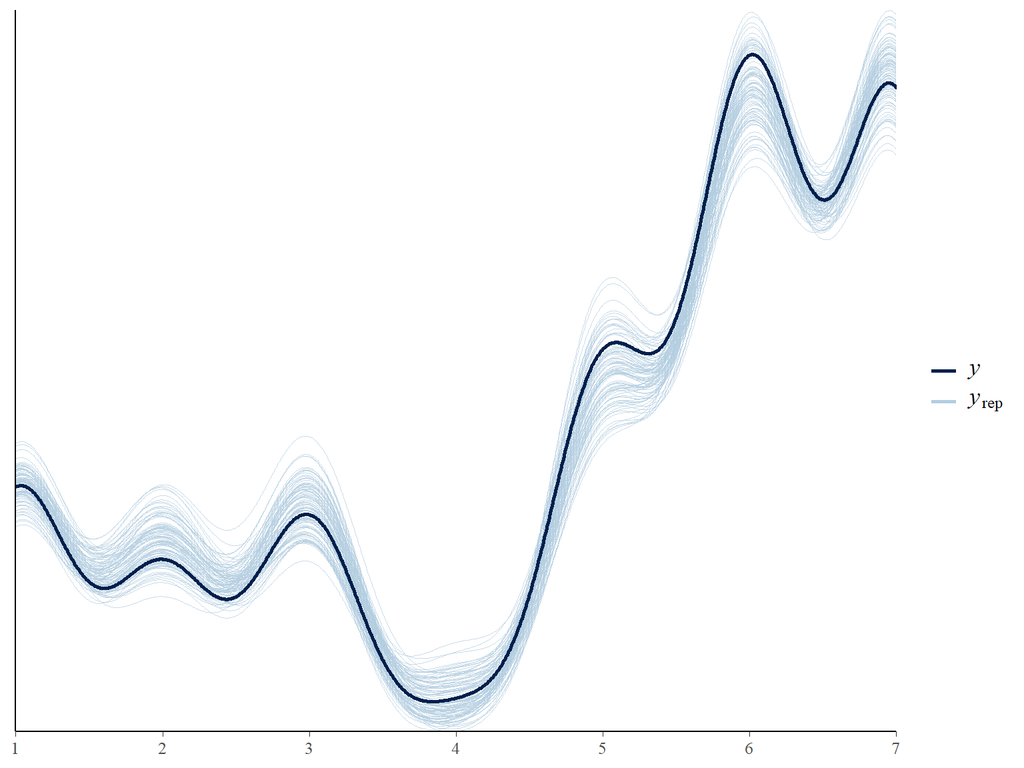

```r
pp_check(E1_cont, nsample = 100)
```

Analyze the ratings, categorical model:

```r
E1_cat <- brm(ResponseNum ~ CrossModality +
                 PairAttested + AdjFreq_log10 + NounFreq_log10 +
                 (1 + CrossModality|ID) +
                 (1|Adj) + (1|Noun) + (1|Item),

              data = E1,
              family = cumulative(),

              prior = weak_prior,

              # MCMC variables:

              control = mcmc_controls,
              cores = 4, chains = 4,
              init = 0, seed = 42,
              warmup = 3000, iter = 5000,
              save_all_pars = TRUE)
```

Posterior predictive checks:

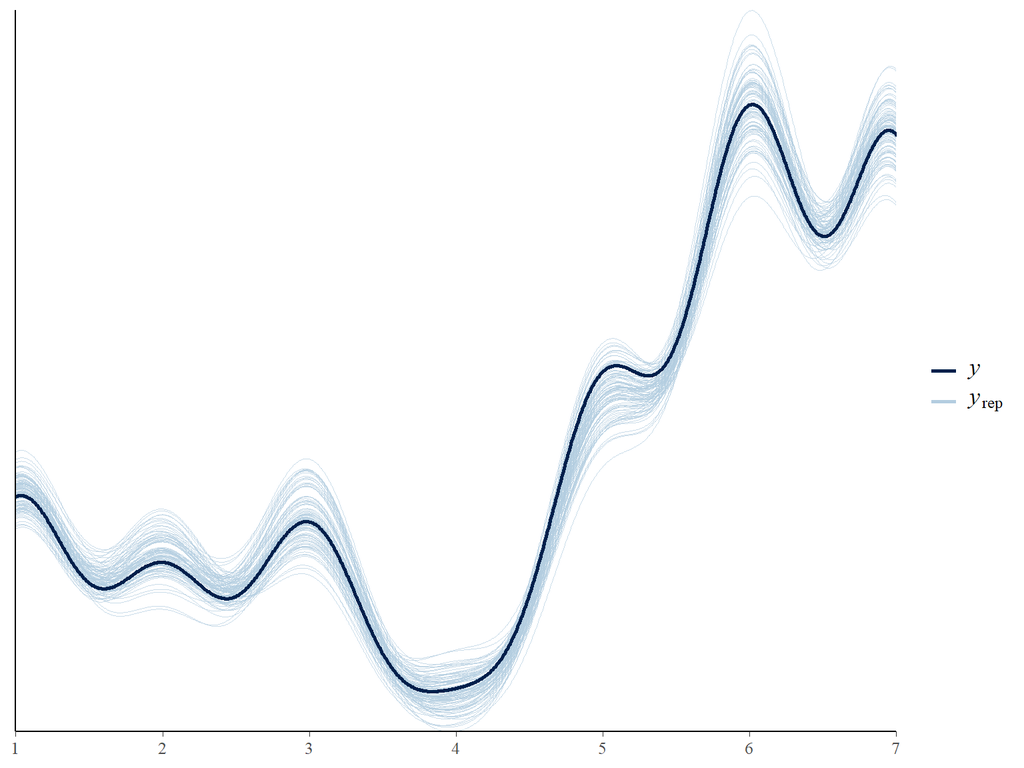

```r
pp_check(E1_cat, nsample = 100)
```

Save the models:

```r
save(E1_cont, file = '../models/E1_cont_mdl.Rdata',
     compress = 'xz', compression_level = 9)
save(E1_cat, file = '../models/E1_cat_mdl.Rdata',
     compress = 'xz', compression_level = 9)
```

Perform LOO:

```r
E1_cont_loo <- loo(E1_cont, moment_match = TRUE)
E1_cat_loo <- loo(E1_cat, moment_match = TRUE)

# compare:

E1_both_loo <- loo_compare(E1_cont_loo, E1_cat_loo)

# show:

E1_both_loo
```

```
##         elpd_diff se_diff
## E1_cont   0.0       0.0
## E1_cat  -30.2      16.2
```

Save LOOs:

```r
save(E1_cont_loo, file = '../models/E1_cont_loo.Rdata',
     compress = 'xz', compression_level = 9)
save(E1_cat_loo, file = '../models/E1_cat_loo.Rdata',
     compress = 'xz', compression_level = 9)
```

Check Bayes R2:

```r
bayes_R2(E1_cat)
```

```
##     Estimate   Est.Error      Q2.5     Q97.5
## R2 0.6040789 0.006042017 0.5919714 0.6157116
```

```r
bayes_R2(E1_cont)
```

```
##     Estimate   Est.Error      Q2.5     Q97.5
## R2 0.6102329 0.006205401 0.5975006 0.6220518
```

Interpret the model:

```r
summary(E1_cont)
```

```
##  Family: cumulative
##   Links: mu = logit; disc = identity
## Formula: ResponseNum ~ Cosine + PairAttested + AdjFreq_log10 + NounFreq_log10 + (1 + Cosine | ID) + (1 | Adj) + (1 | Noun) + (1 | Item)
##    Data: E1 (Number of observations: 2500)
## Samples: 4 chains, each with iter = 5000; warmup = 3000; thin = 1;
##          total post-warmup samples = 8000
##
## Group-Level Effects:
## ~Adj (Number of levels: 21)
##               Estimate Est.Error l-95% CI u-95% CI Rhat Bulk_ESS Tail_ESS
## sd(Intercept)     0.48      0.33     0.02     1.22 1.01      665     1750
##
## ~ID (Number of levels: 50)
##                       Estimate Est.Error l-95% CI u-95% CI Rhat Bulk_ESS
## sd(Intercept)             1.93      0.24     1.51     2.46 1.00     1216
## sd(Cosine)                2.85      0.35     2.23     3.62 1.00     1398
## cor(Intercept,Cosine)    -0.91      0.03    -0.96    -0.84 1.00     1477
##                       Tail_ESS
## sd(Intercept)             2458
## sd(Cosine)                2858
## cor(Intercept,Cosine)     3227
##
## ~Item (Number of levels: 50)
##               Estimate Est.Error l-95% CI u-95% CI Rhat Bulk_ESS Tail_ESS
## sd(Intercept)     1.00      0.17     0.66     1.36 1.01     1193     1965
##
## ~Noun (Number of levels: 18)
##               Estimate Est.Error l-95% CI u-95% CI Rhat Bulk_ESS Tail_ESS
## sd(Intercept)     0.53      0.28     0.04     1.15 1.01      886     1252
##
## Population-Level Effects:
##                      Estimate Est.Error l-95% CI u-95% CI Rhat Bulk_ESS
## Intercept[1]            -5.13      1.79    -8.68    -1.58 1.00     2975
## Intercept[2]            -3.77      1.79    -7.32    -0.25 1.00     2966
## Intercept[3]            -2.65      1.78    -6.17     0.87 1.00     2971
## Intercept[4]            -2.25      1.78    -5.78     1.26 1.00     2970
## Intercept[5]            -1.14      1.78    -4.67     2.38 1.00     2965
## Intercept[6]             0.64      1.78    -2.88     4.14 1.00     2963
## Cosine                  -5.00      0.76    -6.45    -3.49 1.00     1829
## PairAttestedattested    -0.96      0.50    -1.91     0.03 1.00     1800
## AdjFreq_log10            0.44      0.26    -0.07     0.95 1.00     3694
## NounFreq_log10          -0.01      0.37    -0.76     0.70 1.00     3304
##                      Tail_ESS
## Intercept[1]             4473
## Intercept[2]             4439
## Intercept[3]             4328
## Intercept[4]             4438
## Intercept[5]             4322
## Intercept[6]             4367
## Cosine                   3472
## PairAttestedattested     3057
## AdjFreq_log10            4482
## NounFreq_log10           4718
##
## Samples were drawn using sampling(NUTS). For each parameter, Eff.Sample
## is a crude measure of effective sample size, and Rhat is the potential
## scale reduction factor on split chains (at convergence, Rhat = 1).
```

```r
summary(E1_cat)
```

```
##  Family: cumulative
##   Links: mu = logit; disc = identity
## Formula: ResponseNum ~ CrossModality + PairAttested + AdjFreq_log10 + NounFreq_log10 + (1 + CrossModality | ID) + (1 | Adj) + (1 | Noun) + (1 | Item)
##    Data: E1 (Number of observations: 2500)
## Samples: 4 chains, each with iter = 5000; warmup = 3000; thin = 1;
##          total post-warmup samples = 8000
##
## Group-Level Effects:
## ~Adj (Number of levels: 21)
##               Estimate Est.Error l-95% CI u-95% CI Rhat Bulk_ESS Tail_ESS
## sd(Intercept)     0.90      0.33     0.22     1.55 1.00     1427     1427
##
## ~ID (Number of levels: 50)
##                                      Estimate Est.Error l-95% CI u-95% CI Rhat
## sd(Intercept)                            0.99      0.12     0.79     1.24 1.00
## sd(CrossModalityunimodal)                1.91      0.24     1.49     2.43 1.00
## cor(Intercept,CrossModalityunimodal)    -0.68      0.09    -0.83    -0.46 1.00
##                                      Bulk_ESS Tail_ESS
## sd(Intercept)                            1942     4048
## sd(CrossModalityunimodal)                2867     4552
## cor(Intercept,CrossModalityunimodal)     2248     4260
##
## ~Item (Number of levels: 50)
##               Estimate Est.Error l-95% CI u-95% CI Rhat Bulk_ESS Tail_ESS
## sd(Intercept)     0.77      0.20     0.42     1.19 1.00     1184     2761
##
## ~Noun (Number of levels: 18)
##               Estimate Est.Error l-95% CI u-95% CI Rhat Bulk_ESS Tail_ESS
## sd(Intercept)     0.62      0.30     0.07     1.25 1.00     1465     1823
##
## Population-Level Effects:
##                       Estimate Est.Error l-95% CI u-95% CI Rhat Bulk_ESS
## Intercept[1]             -1.93      1.80    -5.49     1.55 1.00     5852
## Intercept[2]             -0.49      1.80    -4.06     2.98 1.00     5815
## Intercept[3]              0.66      1.80    -2.90     4.14 1.00     5803
## Intercept[4]              1.06      1.80    -2.49     4.53 1.00     5812
## Intercept[5]              2.15      1.80    -1.40     5.61 1.00     5824
## Intercept[6]              3.86      1.80     0.31     7.33 1.00     5798
## CrossModalityunimodal    -3.79      0.50    -4.76    -2.77 1.00     3526
## PairAttestedattested     -1.18      0.42    -2.05    -0.39 1.00     3185
## AdjFreq_log10             0.59      0.30     0.01     1.20 1.00     5020
## NounFreq_log10            0.27      0.37    -0.48     0.97 1.00     5832
##                       Tail_ESS
## Intercept[1]              5187
## Intercept[2]              5381
## Intercept[3]              5441
## Intercept[4]              5440
## Intercept[5]              5343
## Intercept[6]              5363
## CrossModalityunimodal     5246
## PairAttestedattested      4009
## AdjFreq_log10             5080
## NounFreq_log10            5425
##
## Samples were drawn using sampling(NUTS). For each parameter, Eff.Sample
## is a crude measure of effective sample size, and Rhat is the potential
## scale reduction factor on split chains (at convergence, Rhat = 1).
```

Check all effects:

```r
E1_posts <- posterior_samples(E1_cont) %>%
  select(b_Cosine:b_NounFreq_log10)

# Extract posteriors:

b_cosine <- E1_posts$b_Cosine
b_attested <- E1_posts$b_PairAttestednot_attested
b_adj <- E1_posts$b_AdjFreq_log10
b_noun <- E1_posts$b_NounFreq_log10
```

Check:

```r
sum(b_cosine > 0) / length(b_cosine)
```

```
## [1] 0
```

```r
sum(b_attested < 0) / length(b_attested)
```

```
## [1] NaN
```

```r
sum(b_adj < 0) / length(b_adj)
```

```
## [1] 0.045625
```

```r
sum(b_noun < 0) / length(b_noun)
```

```
## [1] 0.49775
```

## Bayesian models, Experiment 2:

Analyze the ratings, continuous model:

```r
E2_cont <- brm(ResponseNum ~ Cosine +
                 PairAttested + AdjFreq_log10 + NounFreq_log10 +
                 (1 + Cosine|ID) +
                 (1|Adj) + (1|Noun) + (1|Item),
               data = E2,
               family = cumulative(),

               prior = weak_prior,

               # MCMC variables:

               control = mcmc_controls,
               cores = 4, chains = 4,
               init = 0, seed = 42,
               warmup = 3000, iter = 5000,
               save_all_pars = TRUE)
```

Posterior predictive checks:

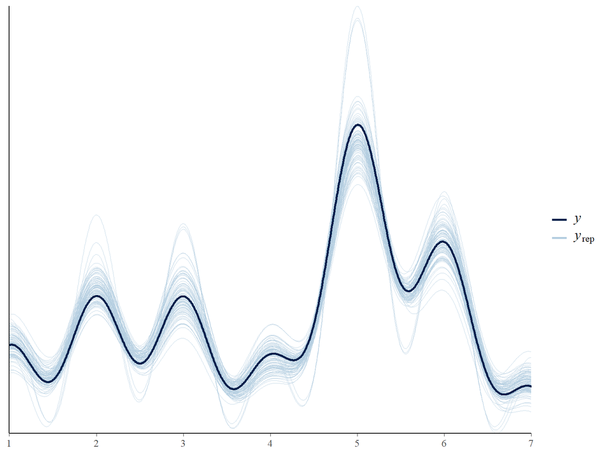

```r
pp_check(E2_cont, nsample = 100)
```

Analyze the ratings, categorical model:

```r
E2_cat <- brm(ResponseNum ~ CrossModality +
                 PairAttested + AdjFreq_log10 + NounFreq_log10 +
                 (1 + CrossModality|ID) +
                 (1|Adj) + (1|Noun) + (1|Item),

              data = E2,
              family = cumulative(),

              prior = weak_prior,

              # MCMC variables:

              control = mcmc_controls,
              cores = 4, chains = 4,
              init = 0, seed = 42,
              warmup = 3000, iter = 5000,
              save_all_pars = TRUE)
```

Posterior predictive checks:

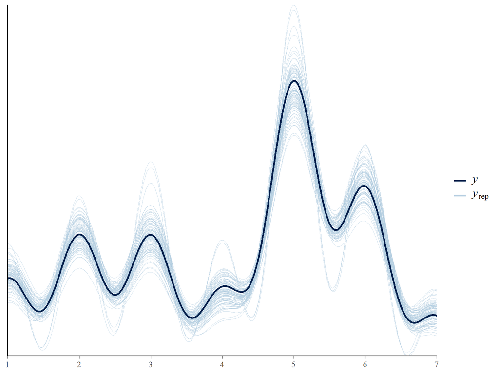

```r
pp_check(E2_cat, nsample = 100)
```

Save the models:

```r
save(E2_cont, file = '../models/E2_cont_mdl.Rdata',
     compress = 'xz', compression_level = 9)
save(E2_cat, file = '../models/E2_cat_mdl.Rdata',
     compress = 'xz', compression_level = 9)
```

Perform LOO:

```r
E2_cont_loo <- loo(E2_cont, moment_match = TRUE)
E2_cat_loo <- loo(E2_cat, moment_match = TRUE)

# compare:

E2_both_loo <- loo_compare(E2_cont_loo, E2_cat_loo)

# show:

E2_both_loo
```

```
##         elpd_diff se_diff
## E2_cont   0.0       0.0
## E2_cat  -18.4      14.3
```

Save LOOs:

```r
save(E2_cont_loo, file = '../models/E2_cont_loo.Rdata',
     compress = 'xz', compression_level = 9)
save(E2_cat_loo, file = '../models/E2_cat_loo.Rdata',
     compress = 'xz', compression_level = 9)
```

Check Bayes R2:

```r
bayes_R2(E2_cat)
```

```
##     Estimate  Est.Error      Q2.5     Q97.5
## R2 0.3737774 0.01044117 0.3524496 0.3936053
```

```r
bayes_R2(E2_cont)
```

```
##     Estimate  Est.Error      Q2.5    Q97.5
## R2 0.3846822 0.01046961 0.3636281 0.404772
```

Interpret the model:

```r
summary(E2_cont)
```

```
##  Family: cumulative
##   Links: mu = logit; disc = identity
## Formula: ResponseNum ~ Cosine + PairAttested + AdjFreq_log10 + NounFreq_log10 + (1 + Cosine | ID) + (1 | Adj) + (1 | Noun) + (1 | Item)
##    Data: E2 (Number of observations: 2400)
## Samples: 4 chains, each with iter = 5000; warmup = 3000; thin = 1;
##          total post-warmup samples = 8000
##
## Group-Level Effects:
## ~Adj (Number of levels: 21)
##               Estimate Est.Error l-95% CI u-95% CI Rhat Bulk_ESS Tail_ESS
## sd(Intercept)     0.50      0.21     0.08     0.93 1.00     1033     1119
##
## ~ID (Number of levels: 48)
##                       Estimate Est.Error l-95% CI u-95% CI Rhat Bulk_ESS
## sd(Intercept)             1.45      0.18     1.14     1.83 1.00     1891
## sd(Cosine)                2.26      0.28     1.78     2.88 1.00     1522
## cor(Intercept,Cosine)    -0.77      0.07    -0.88    -0.61 1.00     1900
##                       Tail_ESS
## sd(Intercept)             3772
## sd(Cosine)                2315
## cor(Intercept,Cosine)     3619
##
## ~Item (Number of levels: 50)
##               Estimate Est.Error l-95% CI u-95% CI Rhat Bulk_ESS Tail_ESS
## sd(Intercept)     0.39      0.14     0.12     0.67 1.00      945     2075
##
## ~Noun (Number of levels: 18)
##               Estimate Est.Error l-95% CI u-95% CI Rhat Bulk_ESS Tail_ESS
## sd(Intercept)     0.39      0.16     0.08     0.75 1.00     1271     1320
##
## Population-Level Effects:
##                      Estimate Est.Error l-95% CI u-95% CI Rhat Bulk_ESS
## Intercept[1]            -5.94      1.18    -8.32    -3.66 1.00     3114
## Intercept[2]            -4.58      1.18    -6.93    -2.29 1.00     3091
## Intercept[3]            -3.67      1.18    -6.02    -1.38 1.00     3076
## Intercept[4]            -3.11      1.18    -5.47    -0.82 1.00     3078
## Intercept[5]            -1.66      1.18    -4.02     0.62 1.00     3080
## Intercept[6]             0.03      1.18    -2.33     2.32 1.00     3078
## Cosine                  -1.88      0.50    -2.85    -0.91 1.00     2282
## PairAttestedattested    -0.49      0.32    -1.14     0.10 1.00     1691
## AdjFreq_log10           -0.03      0.18    -0.40     0.31 1.00     3548
## NounFreq_log10          -0.43      0.23    -0.89     0.03 1.00     4142
##                      Tail_ESS
## Intercept[1]             4434
## Intercept[2]             4277
## Intercept[3]             4300
## Intercept[4]             4362
## Intercept[5]             4302
## Intercept[6]             4238
## Cosine                   4222
## PairAttestedattested     2720
## AdjFreq_log10            4647
## NounFreq_log10           4985
##
## Samples were drawn using sampling(NUTS). For each parameter, Eff.Sample
## is a crude measure of effective sample size, and Rhat is the potential
## scale reduction factor on split chains (at convergence, Rhat = 1).
```

```r
summary(E2_cat)
```

```
##  Family: cumulative
##   Links: mu = logit; disc = identity
## Formula: ResponseNum ~ CrossModality + PairAttested + AdjFreq_log10 + NounFreq_log10 + (1 + CrossModality | ID) + (1 | Adj) + (1 | Noun) + (1 | Item)
##    Data: E2 (Number of observations: 2400)
## Samples: 4 chains, each with iter = 5000; warmup = 3000; thin = 1;
##          total post-warmup samples = 8000
##
## Group-Level Effects:
## ~Adj (Number of levels: 21)
##               Estimate Est.Error l-95% CI u-95% CI Rhat Bulk_ESS Tail_ESS
## sd(Intercept)     0.63      0.17     0.28     0.99 1.01     1223      745
##
## ~ID (Number of levels: 48)
##                                      Estimate Est.Error l-95% CI u-95% CI Rhat
## sd(Intercept)                            0.95      0.12     0.75     1.22 1.00
## sd(CrossModalityunimodal)                1.58      0.21     1.21     2.03 1.00
## cor(Intercept,CrossModalityunimodal)    -0.29      0.15    -0.57     0.03 1.00
##                                      Bulk_ESS Tail_ESS
## sd(Intercept)                            2057     3576
## sd(CrossModalityunimodal)                2222     4271
## cor(Intercept,CrossModalityunimodal)     2324     3859
##
## ~Item (Number of levels: 50)
##               Estimate Est.Error l-95% CI u-95% CI Rhat Bulk_ESS Tail_ESS
## sd(Intercept)     0.19      0.13     0.01     0.50 1.01      665      863
##
## ~Noun (Number of levels: 18)
##               Estimate Est.Error l-95% CI u-95% CI Rhat Bulk_ESS Tail_ESS
## sd(Intercept)     0.51      0.15     0.25     0.85 1.00     1876     2556
##
## Population-Level Effects:
##                       Estimate Est.Error l-95% CI u-95% CI Rhat Bulk_ESS
## Intercept[1]             -4.72      1.15    -7.00    -2.46 1.00     4028
## Intercept[2]             -3.34      1.15    -5.62    -1.06 1.00     4028
## Intercept[3]             -2.43      1.15    -4.72    -0.16 1.00     4031
## Intercept[4]             -1.88      1.15    -4.15     0.40 1.00     4029
## Intercept[5]             -0.46      1.15    -2.76     1.83 1.00     4051
## Intercept[6]              1.19      1.15    -1.12     3.46 1.00     4066
## CrossModalityunimodal    -1.43      0.31    -2.03    -0.81 1.00     2599
## PairAttestedattested     -0.62      0.21    -1.07    -0.23 1.00     2790
## AdjFreq_log10             0.07      0.18    -0.30     0.43 1.00     3022
## NounFreq_log10           -0.34      0.24    -0.84     0.12 1.00     4035
##                       Tail_ESS
## Intercept[1]              4905
## Intercept[2]              4870
## Intercept[3]              4809
## Intercept[4]              4787
## Intercept[5]              4884
## Intercept[6]              4761
## CrossModalityunimodal     4794
## PairAttestedattested      2113
## AdjFreq_log10             4275
## NounFreq_log10            4630
##
## Samples were drawn using sampling(NUTS). For each parameter, Eff.Sample
## is a crude measure of effective sample size, and Rhat is the potential
## scale reduction factor on split chains (at convergence, Rhat = 1).
```

Check all effects:

```r
E2_posts <- posterior_samples(E2_cont) %>%
  select(b_Cosine:b_NounFreq_log10)

# Extract posteriors:

b_cosine <- E2_posts$b_Cosine
b_attested <- E2_posts$b_PairAttestednot_attested
b_adj <- E2_posts$b_AdjFreq_log10
b_noun <- E2_posts$b_NounFreq_log10
```

Check:

```r
sum(b_cosine > 0) / length(b_cosine)
```

```
## [1] 0.000125
```

```r
sum(b_attested > 0) / length(b_attested)
```

```
## [1] NaN
```

```r
sum(b_adj > 0) / length(b_adj)
```

```
## [1] 0.44325
```

```r
sum(b_noun > 0) / length(b_noun)
```

```
## [1] 0.034125
```

## Experiment 1 and 2, coefficient plots

Make a coefficient plot. First make both tables of posterior estimates into long format:

```r
# Experiment 1:

E1_posts_long <- pivot_longer(E1_posts,
                              cols = b_Cosine:b_NounFreq_log10,
                              values_to = 'Estimate',
                              names_to = 'Coefficient')

# Experiment 2:

E2_posts_long <- pivot_longer(E2_posts,
                              cols = b_Cosine:b_NounFreq_log10,
                              values_to = 'Estimate',
                              names_to = 'Coefficient')
```

Get 95% CIs:

```r
# Experiment 1:

E1_coefs <- E1_posts_long %>% group_by(Coefficient) %>%
  summarize(M = mean(Estimate),
            LowerCI = quantile(Estimate, 0.025),
            UpperCI = quantile(Estimate, 0.975))
# Experiment 2:

E2_coefs <- E2_posts_long %>% group_by(Coefficient) %>%
  summarize(M = mean(Estimate),
            LowerCI = quantile(Estimate, 0.025),
            UpperCI = quantile(Estimate, 0.975))
```

Rename the coefficients so that they are prettier for plotting:

```r
# Experiment 1:

E1_coefs <- mutate(E1_coefs,
                   Coefficient = ifelse(Coefficient == 'b_PairAttestednot_attested',
                                        'Corpus attestation', Coefficient),
                   Coefficient = ifelse(Coefficient == 'b_AdjFreq_log10',
                                        'Adjective frequency', Coefficient),
                   Coefficient = ifelse(Coefficient == 'b_NounFreq_log10',
                                        'Noun frequency', Coefficient),
                   Coefficient = ifelse(Coefficient == 'b_Cosine',
                                        'Cosine similarity', Coefficient))

# Experiment 2:

E2_coefs <- mutate(E2_coefs,
                   Coefficient = ifelse(Coefficient == 'b_PairAttestednot_attested',
                                        'Corpus attestation', Coefficient),
                   Coefficient = ifelse(Coefficient == 'b_AdjFreq_log10',
                                        'Adjective frequency', Coefficient),
                   Coefficient = ifelse(Coefficient == 'b_NounFreq_log10',
                                        'Noun frequency', Coefficient),
                   Coefficient = ifelse(Coefficient == 'b_Cosine',
                                        'Cosine similarity', Coefficient))
```

Plot this, Experiment 1:

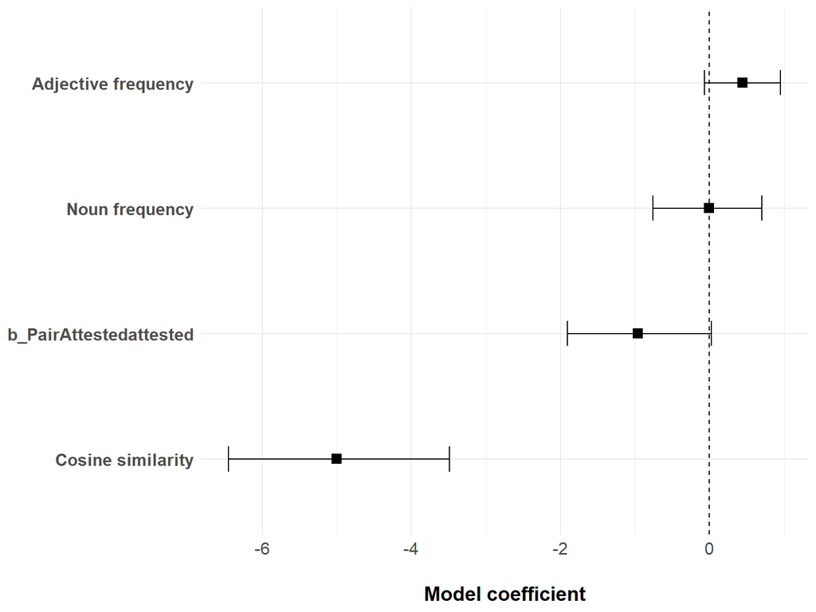

```r
E1_coef_p <- E1_coefs %>%
  ggplot(aes(x = reorder(Coefficient, M), y = M,
             ymin = LowerCI, ymax = UpperCI)) +
  geom_point(pch = 15, size = 3) +
  geom_errorbar(width = 0.2) +
  geom_hline(yintercept = 0, linetype = 2) +
  ylab('Model coefficient') +
  coord_flip() +
  theme_minimal() +
  theme(axis.title.y = element_blank(),
        axis.title.x = element_text(face = 'bold', size = 14,
                                    margin = margin(t = 20, b = 0,
                                                    r = 0, l = 0)),
        axis.text.y = element_text(face = 'bold', size = 12),
        axis.text.x = element_text(size = 12))

# Show and save:
E1_coef_p
```

```r
ggsave(plot = E1_coef_p, filename = '../figures/E1_coefficient_plot.pdf',
       width = 8, height = 6)
```

Plot this, Experiment 2:

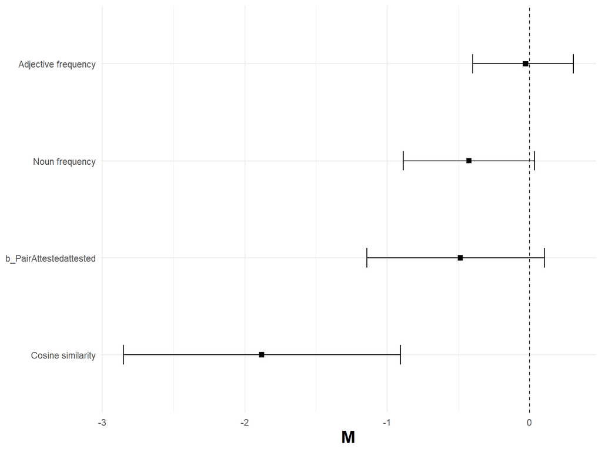

```r
E2_coef_p <- E2_coefs %>%
  ggplot(aes(x = reorder(Coefficient, M), y = M,
             ymin = LowerCI, ymax = UpperCI)) +
  geom_point(pch = 15, size = 2) +
  geom_errorbar(width = 0.2) +
  geom_hline(yintercept = 0, linetype = 2) +
  coord_flip() +
  theme_minimal() +
  xlab('Model coefficient') +
  theme(axis.title.y = element_blank(),
        axis.title.x = element_text(face = 'bold', size = 16))

# Show and save:
E2_coef_p
```

```r
ggsave(plot = E1_coef_p, filename = '../figures/E2_coefficient_plot.pdf',
       width = 8, height = 6)
```

Put them both into the same plot:

```r
E1_coef_p <- E1_coef_p + ggtitle('(a) Experiment 1') +
  theme(plot.title = element_text(face = 'bold', size = 18,
                                  margin = margin(b = 20, t = 0,
                                                  r = 0, l = 0)))
E2_coef_p <- E2_coef_p + ggtitle('(b) Experiment 2') +
  theme(plot.title = element_text(face = 'bold', size = 18,
                                  margin = margin(b = 20, t = 0,
                                                  r = 0, l = 0)))

# Save:

both_coef_p <- E1_coef_p + E2_coef_p
ggsave(plot = both_coef_p, filename = '../figures/both_coefficient_plots.pdf',
       width = 12, height = 6)
```

This completes this analysis.